# MovieLens Project Report

Nick Wade

12/19/2019

## Introduction

Machine learning is an extremely important tool in modern-day business. It can used to describe data about a customer base as a whole or personalaize an experience for each individual user. The aim of machine learning is to process data into a helpfuls. Effective machine learning algorithms have attracted a lot of attention in recent years; for example, Netflix casted a seven-figure bounty on a verifiable improvemnent to their movie recommendation system.

This report seeks to build off the Netflix challenge premise and, more specifically, to predict movie ratings a large data set of movie ratings by users. We train a machine learning algorithm to generate predicted movie ratings and calculate the Root Mean Square Error (RMSE) of predicted ratings and actual ratings.

The report is composed of four parts: the introduction that has presented the problem, the summary describes the dataset and develops preliminary inquiries, the methods section establishes the model being implemented and follows the accompanying .R file in application, and the conclusion section shares the results.

## Summary

We use the [MovieLens 10M dataset](https://grouplens.org/datasets/movielens/10m/) that consists of 10 million ratings and 100,000 tag applications applied to 10,000 movies by 72,000 users. This leads to wildly varying numbers of ratings for each movie, with the most rated movie being *Pulp Fiction* (1994) with over 31,000 ratings and over 100 titles with a single rating.

```r
# Most rated films
edx %>% group_by(title) %>%
  summarize(n_ratings = n()) %>%
  arrange(desc(n_ratings))
```

```
## # A tibble: 10,676 x 2
##    title                                                        n_ratings
##    <chr>                                                            <int>
##  1 Pulp Fiction (1994)                                              31362
##  2 Forrest Gump (1994)                                              31079
##  3 Silence of the Lambs, The (1991)                                 30382
##  4 Jurassic Park (1993)                                             29360
##  5 Shawshank Redemption, The (1994)                                 28015
##  6 Braveheart (1995)                                                26212
##  7 Fugitive, The (1993)                                             25998
##  8 Terminator 2: Judgment Day (1991)                                25984
##  9 Star Wars: Episode IV - A New Hope (a.k.a. Star Wars) (1977)     25672
## 10 Apollo 13 (1995)                                                 24284
## # … with 10,666 more rows
```

```r
# Number of movies rated once
edx %>% group_by(title) %>%
  summarize(n_ratings = n()) %>%
  filter(n_ratings==1) %>%
  count() %>% pull()
```

```
## [1] 126
```

Due to the size of the dataset, built-in machine learning algorithms using R packages such as *caret* would require too much resources for a laptop to run in a timely manner if at all. Therefore, we achieve our goal using a linear model developed in the methods section of this report. The RMSE function is used from the DescTools package as the measure of accuracy.

The dataset we use is split 90-10 on train and test sets respectively. This is completed in the first steps of the script. The training (edx) dataset has 9,000,055 entries with 6 columns. Similarly, the test (validation) dataset has 999,999 entries and 6 columns. The column information is shown below for the validation dataset.

```r
glimpse(validation)
```

```
## Observations: 999,999
## Variables: 6
## $ userId    <int> 1, 1, 1, 2, 2, 2, 3, 3, 4, 4, 4, 5, 5, 5, 5, 5, 5, 5, 5, 5,…
## $ movieId   <dbl> 231, 480, 586, 151, 858, 1544, 590, 4995, 34, 432, 434, 85,…
## $ rating    <dbl> 5.0, 5.0, 5.0, 3.0, 2.0, 3.0, 3.5, 4.5, 5.0, 3.0, 3.0, 3.0,…
## $ timestamp <int> 838983392, 838983653, 838984068, 868246450, 868245645, 8682…
## $ title     <chr> "Dumb & Dumber (1994)", "Jurassic Park (1993)", "Home Alone…
## $ genres    <chr> "Comedy", "Action|Adventure|Sci-Fi|Thriller", "Children|Com…
```

## Methods

The simplest model we can use is use the average across every user and every movie as every one of our predicted ratings. This model follows the simple equation, $Y_{u,i} = \mu$, where $Y_{u,i}$ is the predicted rating at user $u$ and movie $i$ and $/mu$ is the average rating across all entries. This is calculated as 3.512 (`mean(edx$rating)`).

```r
mu <- mean(edx$rating)
RMSE(validation$rating, mu)
```

```
## [1] 1.061202
```

In order to improve our model, we add an independent error term $\epsilon_{u,i}$ that expresses ratings differences for users and movies. We will add the user bias term later, but for now we add the movie bias term $b_i$. This term looks to average the ranking for any movie $i$ because some are liked more than others. The new model is $Y_{u,i} = \mu + b_{i}$.

```r
# add movie bias term, b_i
b_i <- edx %>%
  group_by(movieId) %>%
  summarize(b_i = mean(rating - mu))

# predict all unknown ratings with mu and b_i
predicted_ratings <- validation %>%
  left_join(b_i, by='movieId') %>%
  mutate(pred = mu + b_i) %>%
  pull(pred)

# calculate RMSE of movie ranking effect
RMSE(validation$rating, predicted_ratings)
```

```
## [1] 0.9439087
```

Now we introduce the user bias term $b_u$ in order to further improve our model. This term minimizes the effect of extreme ratings made by users that either love or hate every movie. Each user $u$ is given a bias term that sways their predicted movies. Our updated model is now $Y_{u,i} = \mu + b_{i} + b_{u}$.

```r
b_u <- edx %>%
  left_join(b_i, by='movieId') %>%
  group_by(userId) %>%
  summarize(b_u = mean(rating - mu - b_i))

# predict new ratings with movie and user bias
predicted_ratings <- validation %>%
  left_join(b_i, by='movieId') %>%
  left_join(b_u, by='userId') %>%
  mutate(pred = mu + b_i + b_u) %>%
  pull(pred)

# calculate RMSE of movie and user bias effect
RMSE(predicted_ratings, validation$rating)
```

```
## [1] 0.8653488
```

Finally, we employ regularization to reduce the effect of large errors in our predictions. Regularization penalizes incorrect estimates on small sample sizes. For instance, our $b_i$ term accounts for the average deviation on all ratings of a movie, whether there is 1 or 100 ratings to the movie. We use regularization to reduce the dramatic effect that a exceptionally extreme rating will have on our $b_i$ term. This method is also applied to the user bias term $b_u$ to reduce large anomalies.

Regularization achieves the same goal as confidence intervals when you only are able to predict a single number, not an interval. Our new model is:

$$\begin{equation}
\frac{1}{N} \sum_{u,i}(Y_{u,i} - \mu - b_i - b_u)^2 + \lambda (\sum_{i} b_i^2 + \sum_u b_u^2),
\end{equation}$$

where the first term is our previous least squares equation and the last term is the penalty with large bias terms. Minimizing the biases using a single $\lamda$ is the goal to our model shown above. We test `lamda <- seq(from=0, to=10, by=0.25)` and plot the results below:

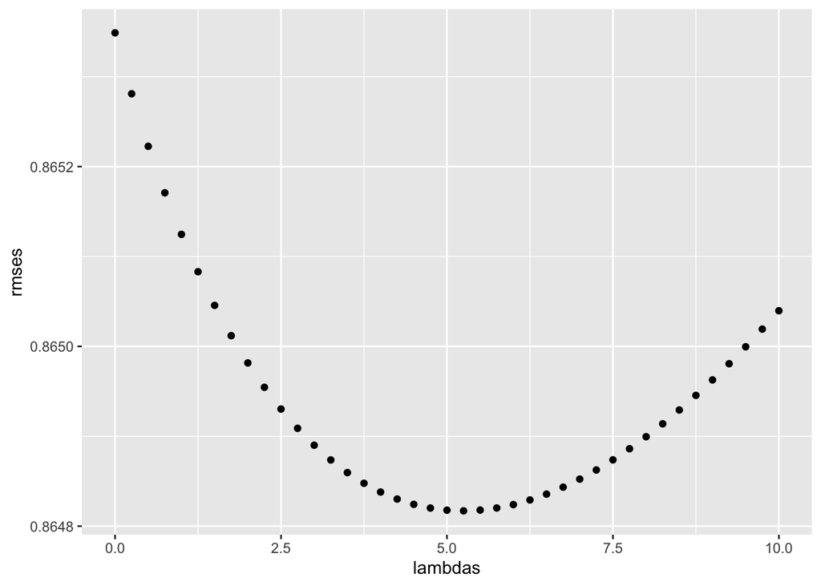

```r
qplot(lambdas, rmses)
```

We see that the minimizing $\lambda$ term is

```r
lambdas[which.min(rmses)]
```

```
## [1] 5.25
```

## Results

For completeness, the final model is ran below:

```r
# choose minimized lambda
lam <- lambdas[which.min(rmses)]

# compute regularize movie bias term
b_i <- edx %>%
  group_by(movieId) %>%
  summarize(b_i = sum(rating - mu)/(n()+lam))

# compute regularize user bias term
b_u <- edx %>%
  left_join(b_i, by="movieId") %>%
  group_by(userId) %>%
  summarize(b_u = sum(rating - b_i - mu)/(n()+lam))

# compute predictions on validation set based on these above terms
predicted_ratings <- validation %>%
  left_join(b_i, by = "movieId") %>%
  left_join(b_u, by = "userId") %>%
  mutate(pred = mu + b_i + b_u) %>%
  pull(pred)

# output RMSE of our final model
RMSE(predicted_ratings, validation$rating)
```

```
## [1] 0.864817
```

We can see incremental improvements to the RMSE as we supplant our model with bias terms and regularization.

| Method | RMSE |
| --- | --- |
| Average | 1.06120 |
| Movie effect | 0.94391 |
| Movie and user effects | 0.86535 |
| Regularized movie and user effect | 0.86481 |

Our model is significantly more efficient than machine learning algorithms from R packages applied to this large data set. Because of the simplicity of the linear model, we are able to predict movie ratings without a serious toll on the computer resources.